# Tooploox_ver2

Shilpa Khichar

2 January 2017

```r
requiredPackages <- c("Hmisc","caret","ggplot2","reshape2", "mice")
if (length(setdiff(requiredPackages, rownames(installed.packages()))) > 0) {
     install.packages(setdiff(requiredPackages, rownames(installed.packages())))
  }
```

```r
library(Hmisc)
library(caret)
```

```r
library(ggplot2)
library(reshape2)
library(mice)
```

# Fetching data

reading csv file and defining headers as Id and View_Hour_1:168, as csv file didnot had header

```r
data_Video_views <- read.csv(file.path(getwd(),"Tooploox.csv"), header=FALSE, sep=",", encoding="UTF-8")
names(data_Video_views)[1] <- "Id"
names(data_Video_views)[2:169] <-sprintf("View_hour_%d",1:168)
```

# Basic Statistics

Analysing Basic Statistics for Video View Hours ->24,72,168

```r
summary(data_Video_views$View_hour_24)
```

```
##     Min.  1st Qu.   Median     Mean  3rd Qu.     Max.
##    21170   124900   194400   376800   326700 15280000
```

```r
summary(data_Video_views$View_hour_72)
```

```
##     Min.  1st Qu.   Median     Mean  3rd Qu.     Max.
##    26160   148300   237400   613300   433600 22920000
```

```r
summary(data_Video_views$View_hour_168)
```

```
##     Min.  1st Qu.   Median     Mean  3rd Qu.     Max.
##    27140   153300   252300   743200   522300 27900000
```

Here we see that Mean is greater then Median and even 3rd Quantile.. Lets see the plots

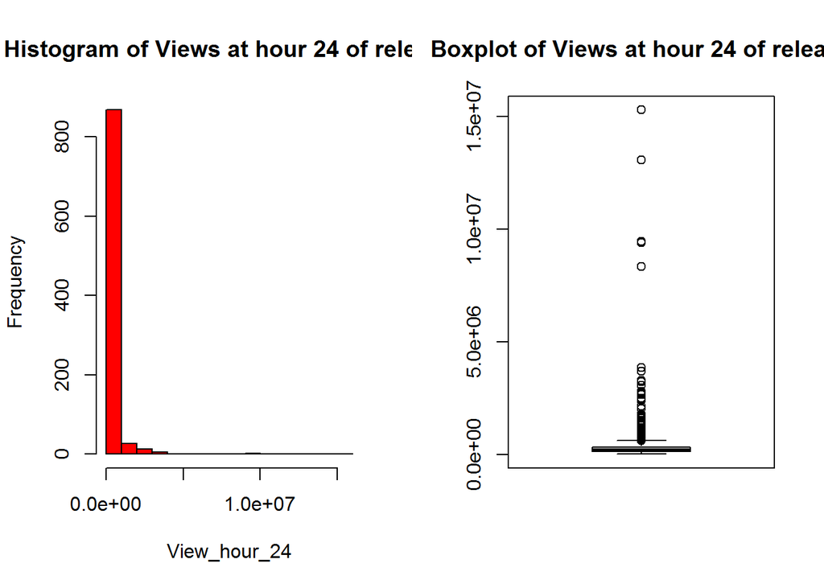

```r
attach(data_Video_views )
par(mfrow=c(1,2))
hist(View_hour_24, main="Histogram of Views at hour 24 of release" ,col= "red")
boxplot(View_hour_24, main="Boxplot of Views at hour 24 of release")
```

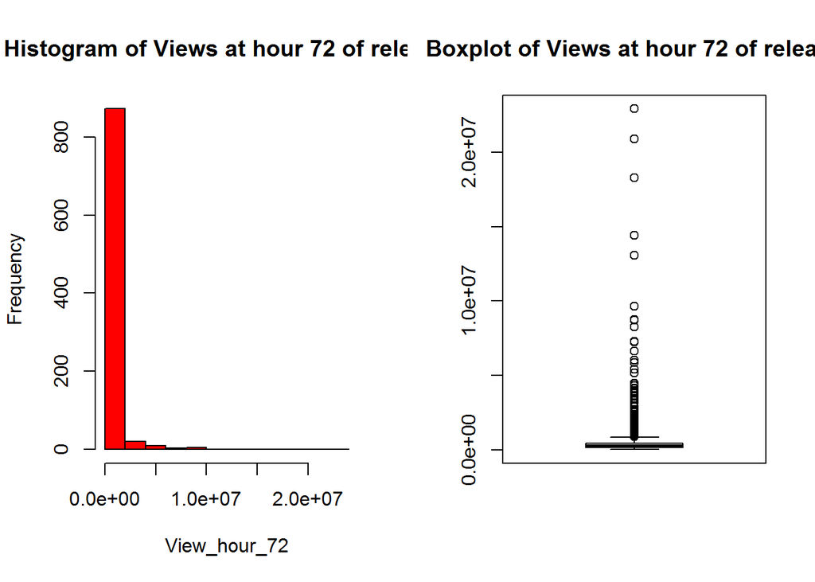

```r
par(mfrow=c(1,2))
hist(View_hour_72, main="Histogram of Views at hour 72 of release",col= "red")
boxplot(View_hour_72, main="Boxplot of Views at hour 72 of release")
```

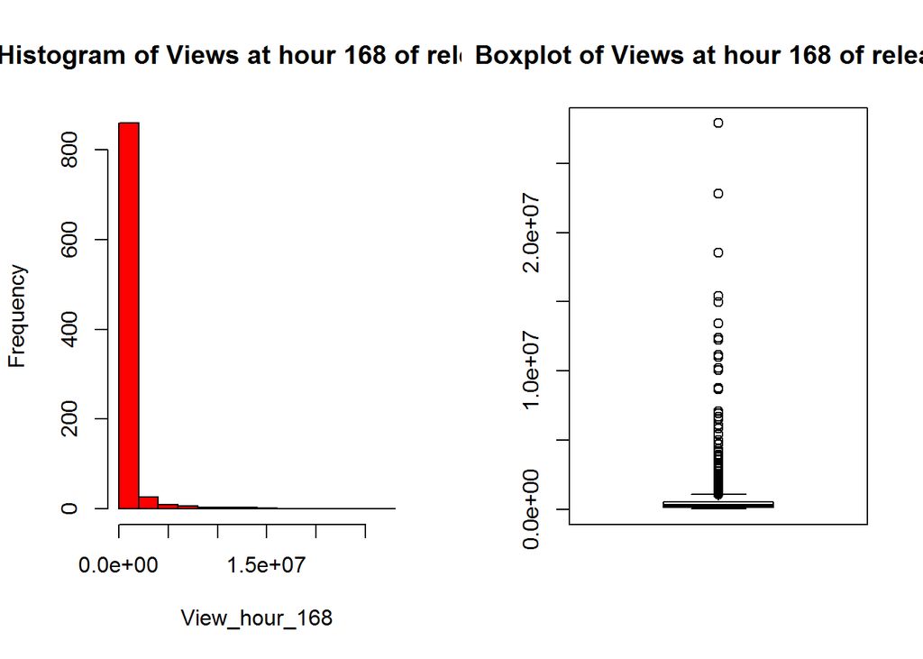

```r
par(mfrow=c(1,2))
hist(View_hour_168, main="Histogram of Views at hour 168 of release",col= "red")
boxplot(View_hour_168, main="Boxplot of Views at hour 168 of release")
```

Here we also see that for a few Videos the View Values are very high..must be very HIT videos, but in our case/study we should treat them as outliers.

From the BoxPlot we can summarise that the Mean has high value because of those fewer very HIT videos.

Next we analyse more basic statistics(missing values , Distinct values, top 5, lowest 5 values) using DESCRIBE function..

```r
describe.vector(data_Video_views$View_hour_24)
```

```
## data_Video_views$View_hour_24
##        n  missing distinct     Info     Mean      Gmd      .05      .10
##      916        0      914        1   376766   424144    69196    85906
##      .25      .50      .75      .90      .95
##   124866   194358   326667   581517  1017517
##
## lowest :    21173    23187    26473    30610    33363
## highest:  8339724  9406252  9457966 13073549 15284639
```

```r
describe.vector(data_Video_views$View_hour_72)
```

```
## data_Video_views$View_hour_72
##        n  missing distinct     Info     Mean      Gmd      .05      .10
##      916        0      916        1   613303   802985    80288   100956
##      .25      .50      .75      .90      .95
##   148326   237418   433612  1031127  1857396
##
## lowest :    26162    26713    31295    35701    39223
## highest: 13087778 14434260 18307225 20879607 22916701
```

```r
describe.vector(data_Video_views$View_hour_168)
```

```
## data_Video_views$View_hour_168
##        n  missing distinct     Info     Mean      Gmd      .05      .10
##      916        0      914        1   743210  1018118    81719   104216
##      .25      .50      .75      .90      .95
##   153346   252287   522259  1324281  2403244
##
## lowest :    27139    27823    32735    37648    41217
## highest: 14978083 15415606 18545642 22828673 27898237
```

```r
quantile(data_Video_views$View_hour_24 ,probs=seq(.80,.99,.02))
```

```
##       80%       82%       84%       86%       88%       90%       92%
##  391741.0  420829.0  444591.4  479980.9  519988.8  581516.5  710304.2
##       94%       96%       98%
##  890404.5 1206948.4 2312358.1
```

```r
quantile(data_Video_views$View_hour_72 ,probs=seq(.80,.99,.02))
```

```
##       80%       82%       84%       86%       88%       90%       92%
##  547611.0  595771.7  637125.2  712389.3  849869.0 1031126.5 1200609.0
##       94%       96%       98%
## 1693290.1 2539861.6 4448944.0
```

```r
quantile(data_Video_views$View_hour_168 ,probs=seq(.80,.99,.02))
```

```
##       80%       82%       84%       86%       88%       90%       92%
##  639364.0  689554.9  771695.0  892037.9 1050531.4 1324281.0 1652193.0
##       94%       96%       98%
## 2031155.4 3082422.2 6526004.3
```

We see that there are no missing values at all and hardly any repeating values/Views for that hour…we also see that there is huge difference between top5 and lowest 5 values… Since the Mean is greater then Median and 3rd Quarter, so we look how the distribution is among top 20% values using QUANTILE function… # Log transformation

```r
data_Video_views$View_hour_168_log = log(data_Video_views$View_hour_168)
View_hour_168_log_mean = mean(data_Video_views$View_hour_168_log)
View_hour_168_log_sd = sd(data_Video_views$View_hour_168_log)

attach(data_Video_views)
```

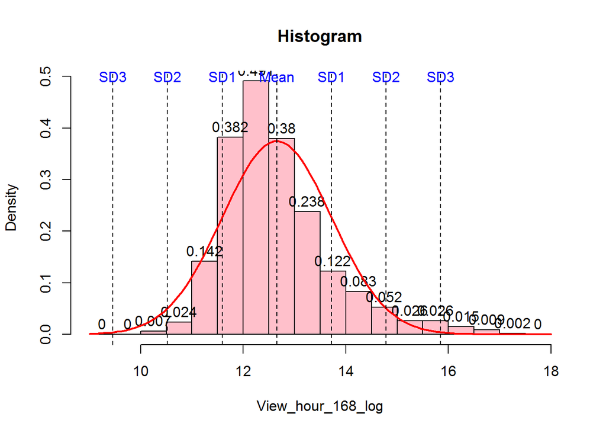

```r
#hist(View_hour_168_log ,breaks=seq(8,20,by=.05))
hist(View_hour_168_log , main="Histogram",xlab="View_hour_168_log",col="pink",label=TRUE,plot = TRUE, freq = F,breaks=seq(9,18,by=.5))
curve(dnorm(x, mean=View_hour_168_log_mean, sd=View_hour_168_log_sd), col="red", lwd=2, add=TRUE, yaxt="n")

abline(v = c(View_hour_168_log_mean,
             View_hour_168_log_mean+View_hour_168_log_sd,
             View_hour_168_log_mean-View_hour_168_log_sd,
             View_hour_168_log_mean+2*View_hour_168_log_sd,
             View_hour_168_log_mean-2*View_hour_168_log_sd,
             View_hour_168_log_mean+3*View_hour_168_log_sd,
             View_hour_168_log_mean-3*View_hour_168_log_sd), lty = 2)

text(x=View_hour_168_log_mean, y=0.5, labels='Mean', col='blue')
text(x=View_hour_168_log_mean+View_hour_168_log_sd, y=0.5, labels='SD1', col='blue')
text(x=View_hour_168_log_mean-View_hour_168_log_sd, y=0.5, labels='SD1', col='blue')
text(x=View_hour_168_log_mean+2*View_hour_168_log_sd, y=0.5, labels='SD2', col='blue')
text(x=View_hour_168_log_mean-2*View_hour_168_log_sd, y=0.5, labels='SD2', col='blue')
text(x=View_hour_168_log_mean+3*View_hour_168_log_sd, y=0.5, labels='SD3', col='blue')
text(x=View_hour_168_log_mean-3*View_hour_168_log_sd, y=0.5, labels='SD3', col='blue')
```

```r
data_Video_views_wo_outliers = subset(data_Video_views,
                                     ( View_hour_168_log >= View_hour_168_log_mean-3*View_hour_168_log_sd)
                                     & (View_hour_168_log <= View_hour_168_log_mean +3*View_hour_168_log_sd))
nrow(data_Video_views_wo_outliers)
```

```
## [1] 901
```

```r
attach(data_Video_views_wo_outliers)
```